# Assignment 5

Gabriela Serrano Echenagucia

2022 April 3

# **Tree-based and Ensemble Methods**

```r
# Load the dataset "parkinsons_updrs"
Parkinsons = read.csv("~/Library/Mobile Documents/com~apple~CloudDocs/Desktop/Univ Miami/6th Semester - SPRING 2022/CSC 597/Assignments/Datasets/Regression/parkinsons_updrs.data")
```

```r
# Load the dataset "breast-cancer-wisconsin.data"
BC = read.csv("~/Library/Mobile Documents/com~apple~CloudDocs/Desktop/Univ Miami/6th Semester - SPRING 2022/CSC 597/Assignments/Datasets/Classification/breast-cancer-wisconsin.data")

# Assign names ot the columns
colnames(BC) <- c("sample.num","clump.thickness","uniformity.size","uniformity.shape","marginal.adh","single.size","nuclei","chromatin","nucleoli","mitoses","tumor")

# Missing values are represented with '?' char. So, replace with NA
BC[BC == '?'] <- NA

# Omit missing values
BC = na.omit(BC)

# For some reason R was reading column 7 as class: "char". So, change everything to numeric
BC = as.data.frame(apply(BC, 2, as.numeric))

# Convert 2 and 4 to 0 and 1, respectively
# 2 = 0 = benign
BC$tumor[BC$tumor=="2"] <- 0
# 4 = 1 = malign
BC$tumor[BC$tumor=="4"] <- 1

# Convert tumor (classification variable) to a factor
BC$tumor <- as.factor(BC$tumor)

# We make sure that this is true: (0 = 0 = benign) and (1 = 1 = malign), for the predictions part
contrasts(BC$tumor)
```

```
  1
0 0
1 1
```

```r
# Set seed
set.seed(42)
```

## 0. Divide the input datasets into training and testing (80:20)

```r
# Parkinsons
dt1 = sort(sample(nrow(Parkinsons), nrow(Parkinsons)*.8))
P.train = Parkinsons[dt1,] # 4700 obs out of 5875 (or 80 %)
P.test = Parkinsons[-dt1,] # 1175 obs out of 5875 (or 20 %)

  # Training
  P.train
```

|  | subject. | age | sex | test_time | motor_UPDRS | total_UPDRS | Jitter... | Jitter.Abs. | Jitter.RAP | Jitter.PPQ5 | Jitter.DDP | Shimmer | Shimmer.dB. | Shimmer.APQ3 | Shimmer.APQ5 | Shimmer.APQ11 | Shimmer.DDA | NHR | HNR | RPDE | DFA | PPE |
| --- | --- | --- | --- | --- | --- | --- | --- | --- | --- | --- | --- | --- | --- | --- | --- | --- | --- | --- | --- | --- | --- | --- |
| 1 | 1 | 72 | 0 | 5.6431 | 28.199 | 34.398 | 0.00662 | 0.00003380 | 0.00401 | 0.00317 | 0.01204 | 0.02565 | 0.230 | 0.01438 | 0.01309 | 0.01662 | 0.04314 | 0.014290 | 21.640 | 0.41888 | 0.54842 | 0.160060 |
| 2 | 1 | 72 | 0 | 12.6660 | 28.447 | 34.894 | 0.00300 | 0.00001680 | 0.00132 | 0.00150 | 0.00395 | 0.02024 | 0.179 | 0.00994 | 0.01072 | 0.01689 | 0.02982 | 0.011112 | 27.183 | 0.43493 | 0.56477 | 0.108100 |
| 3 | 1 | 72 | 0 | 19.6810 | 28.695 | 35.389 | 0.00481 | 0.00002462 | 0.00205 | 0.00208 | 0.00616 | 0.01675 | 0.181 | 0.00734 | 0.00844 | 0.01458 | 0.02202 | 0.020220 | 23.047 | 0.46222 | 0.54405 | 0.210140 |
| 4 | 1 | 72 | 0 | 25.6470 | 28.905 | 35.810 | 0.00528 | 0.00002657 | 0.00191 | 0.00264 | 0.00573 | 0.02309 | 0.327 | 0.01106 | 0.01265 | 0.01963 | 0.03317 | 0.027837 | 24.445 | 0.48730 | 0.57794 | 0.332770 |
| 5 | 1 | 72 | 0 | 33.6420 | 29.187 | 36.375 | 0.00335 | 0.00002014 | 0.00093 | 0.00130 | 0.00278 | 0.01703 | 0.176 | 0.00679 | 0.00929 | 0.01819 | 0.02036 | 0.011625 | 26.126 | 0.47188 | 0.56122 | 0.193610 |
| 7 | 1 | 72 | 0 | 47.6490 | 29.682 | 37.363 | 0.00422 | 0.00002404 | 0.00212 | 0.00221 | 0.00637 | 0.04352 | 0.445 | 0.02376 | 0.02621 | 0.03488 | 0.07128 | 0.013260 | 22.506 | 0.49250 | 0.54779 | 0.175630 |
| 8 | 1 | 72 | 0 | 54.6400 | 29.928 | 37.857 | 0.00476 | 0.00002471 | 0.00226 | 0.00259 | 0.00678 | 0.02191 | 0.212 | 0.00979 | 0.01462 | 0.01911 | 0.02937 | 0.027969 | 22.929 | 0.47712 | 0.54234 | 0.238440 |
| 9 | 1 | 72 | 0 | 61.6690 | 30.177 | 38.353 | 0.00432 | 0.00002854 | 0.00156 | 0.00207 | 0.00468 | 0.04296 | 0.371 | 0.01774 | 0.02134 | 0.03451 | 0.05323 | 0.013381 | 22.078 | 0.51563 | 0.61864 | 0.200370 |
| 10 | 1 | 72 | 0 | 68.6880 | 30.424 | 38.849 | 0.00496 | 0.00002702 | 0.00258 | 0.00253 | 0.00773 | 0.03610 | 0.310 | 0.02030 | 0.01970 | 0.02569 | 0.06089 | 0.018021 | 22.606 | 0.50032 | 0.58673 | 0.201170 |
| 11 | 1 | 72 | 0 | 75.6530 | 30.670 | 39.340 | 0.00465 | 0.00002553 | 0.00238 | 0.00260 | 0.00715 | 0.02132 | 0.188 | 0.01069 | 0.01214 | 0.01844 | 0.03206 | 0.017443 | 25.672 | 0.49892 | 0.61068 | 0.173870 |

[output cut: 990 more lines]

```r
  # Testing
  P.test
```

|  | subject. | age | sex | test_time | motor_UPDRS | total_UPDRS | Jitter... | Jitter.Abs. | Jitter.RAP | Jitter.PPQ5 | Jitter.DDP | Shimmer | Shimmer.dB. | Shimmer.APQ3 | Shimmer.APQ5 | Shimmer.APQ11 | Shimmer.DDA | NHR | HNR | RPDE | DFA | PPE |
| --- | --- | --- | --- | --- | --- | --- | --- | --- | --- | --- | --- | --- | --- | --- | --- | --- | --- | --- | --- | --- | --- | --- |
| 6 | 1 | 72 | 0 | 40.6520 | 29.4350 | 36.8700 | 0.00353 | 0.00002290 | 0.00119 | 0.00159 | 0.00357 | 0.02227 | 0.214 | 0.01006 | 0.01337 | 0.02263 | 0.03019 | 0.009438 | 22.946 | 0.53949 | 0.57243 | 0.195000 |
| 14 | 1 | 72 | 0 | 96.6330 | 31.7760 | 41.0340 | 0.00354 | 0.00002388 | 0.00142 | 0.00150 | 0.00427 | 0.02107 | 0.171 | 0.00847 | 0.01040 | 0.01920 | 0.02540 | 0.015008 | 24.614 | 0.61348 | 0.60661 | 0.158810 |
| 21 | 1 | 72 | 0 | 145.6400 | 35.0430 | 45.3900 | 0.00285 | 0.00001646 | 0.00079 | 0.00109 | 0.00237 | 0.01524 | 0.133 | 0.00567 | 0.00682 | 0.01299 | 0.01702 | 0.004652 | 25.181 | 0.42536 | 0.54735 | 0.169460 |
| 22 | 1 | 72 | 0 | 152.6400 | 35.5090 | 46.0130 | 0.00629 | 0.00003574 | 0.00278 | 0.00293 | 0.00835 | 0.03791 | 0.338 | 0.01915 | 0.02174 | 0.03315 | 0.05745 | 0.043582 | 20.757 | 0.58088 | 0.56681 | 0.279240 |
| 28 | 1 | 72 | 0 | 25.6470 | 28.9050 | 35.8100 | 0.00340 | 0.00002050 | 0.00178 | 0.00162 | 0.00533 | 0.01452 | 0.157 | 0.00711 | 0.00765 | 0.00926 | 0.02132 | 0.016636 | 25.986 | 0.42271 | 0.56963 | 0.117740 |
| 31 | 1 | 72 | 0 | 47.6490 | 29.6820 | 37.3630 | 0.00772 | 0.00003973 | 0.00437 | 0.00420 | 0.01310 | 0.05514 | 0.506 | 0.03163 | 0.03072 | 0.03860 | 0.09490 | 0.018124 | 20.744 | 0.41898 | 0.54621 | 0.218980 |
| 34 | 1 | 72 | 0 | 68.6880 | 30.4240 | 38.8490 | 0.00340 | 0.00001733 | 0.00161 | 0.00174 | 0.00482 | 0.03739 | 0.316 | 0.02120 | 0.02195 | 0.03069 | 0.06360 | 0.005567 | 25.399 | 0.45462 | 0.56983 | 0.162910 |
| 41 | 1 | 72 | 0 | 117.6700 | 33.1780 | 42.9040 | 0.00806 | 0.00004270 | 0.00427 | 0.00434 | 0.01280 | 0.05175 | 0.499 | 0.02832 | 0.03328 | 0.03906 | 0.08495 | 0.030945 | 20.889 | 0.54135 | 0.59130 | 0.239740 |
| 42 | 1 | 72 | 0 | 124.6400 | 33.6430 | 43.5240 | 0.00656 | 0.00003773 | 0.00332 | 0.00365 | 0.00995 | 0.03085 | 0.329 | 0.01393 | 0.01734 | 0.02570 | 0.04180 | 0.036457 | 23.588 | 0.47106 | 0.60709 | 0.242460 |
| 45 | 1 | 72 | 0 | 145.6400 | 35.0430 | 45.3900 | 0.00383 | 0.00002351 | 0.00136 | 0.00168 | 0.00408 | 0.01866 | 0.200 | 0.00858 | 0.01039 | 0.01611 | 0.02575 | 0.013627 | 26.778 | 0.51173 | 0.58429 | 0.165170 |

[output cut: 990 more lines]

```r
# Breast Cancer
dt2 = sort(sample(nrow(BC), nrow(BC)*.8))
BC.train = BC[dt2,] # 545 obs out of 682 (or 80 %)
BC.test = BC[-dt2,] # 137 obs out of 682 (or 20 %)

  # Training Set
  BC.train
```

|  | sample.num | clump.thickness | uniformity.size | uniformity.shape | marginal.adh | single.size | nuclei | chromatin | nucleoli | mitoses | tumor |
| --- | --- | --- | --- | --- | --- | --- | --- | --- | --- | --- | --- |
| 1 | 1002945 | 5 | 4 | 4 | 5 | 7 | 10 | 3 | 2 | 1 | 0 |
| 2 | 1015425 | 3 | 1 | 1 | 1 | 2 | 2 | 3 | 1 | 1 | 0 |
| 3 | 1016277 | 6 | 8 | 8 | 1 | 3 | 4 | 3 | 7 | 1 | 0 |
| 4 | 1017023 | 4 | 1 | 1 | 3 | 2 | 1 | 3 | 1 | 1 | 0 |
| 5 | 1017122 | 8 | 10 | 10 | 8 | 7 | 10 | 9 | 7 | 1 | 1 |
| 6 | 1018099 | 1 | 1 | 1 | 1 | 2 | 10 | 3 | 1 | 1 | 0 |
| 7 | 1018561 | 2 | 1 | 2 | 1 | 2 | 1 | 3 | 1 | 1 | 0 |
| 8 | 1033078 | 2 | 1 | 1 | 1 | 2 | 1 | 1 | 1 | 5 | 0 |
| 9 | 1033078 | 4 | 2 | 1 | 1 | 2 | 1 | 2 | 1 | 1 | 0 |
| 10 | 1035283 | 1 | 1 | 1 | 1 | 1 | 1 | 3 | 1 | 1 | 0 |

[output cut: 535 more lines]

```r
  # Testing Set
  BC.test
```

|  | sample.num | clump.thickness | uniformity.size | uniformity.shape | marginal.adh | single.size | nuclei | chromatin | nucleoli | mitoses | tumor |
| --- | --- | --- | --- | --- | --- | --- | --- | --- | --- | --- | --- |
| 19 | 1050718 | 6 | 1 | 1 | 1 | 2 | 1 | 3 | 1 | 1 | 0 |
| 21 | 1054593 | 10 | 5 | 5 | 3 | 6 | 7 | 7 | 10 | 1 | 1 |
| 29 | 1070935 | 3 | 1 | 1 | 1 | 1 | 1 | 2 | 1 | 1 | 0 |
| 33 | 1075123 | 3 | 1 | 2 | 1 | 2 | 1 | 2 | 1 | 1 | 0 |
| 39 | 1099510 | 10 | 4 | 3 | 1 | 3 | 3 | 6 | 5 | 2 | 1 |
| 46 | 1106095 | 4 | 1 | 1 | 3 | 2 | 1 | 3 | 1 | 1 | 0 |
| 49 | 1108449 | 5 | 3 | 3 | 4 | 2 | 4 | 3 | 4 | 1 | 1 |
| 52 | 1110524 | 10 | 5 | 5 | 6 | 8 | 8 | 7 | 1 | 1 | 1 |
| 54 | 1112209 | 8 | 10 | 10 | 1 | 3 | 6 | 3 | 9 | 1 | 1 |
| 63 | 1116998 | 10 | 4 | 2 | 1 | 3 | 2 | 4 | 3 | 10 | 1 |

[output cut: 127 more lines]

## 1. Regression problem: build regression models to predict total_UPDRS (reminder: do not include motor_UPDRS as input to the model) and measure their performance utilizing the test set

```r
# Libraries
library(randomForest)
library(gbm)
library(tree)

# Test var for prediction
test.pk = P.test$total_UPDRS
```

### b. Build a regression model using random forest

**How does the model perform?** A Random Forest model was built for the Parkinsons dataset (regression). We calculated the MSE (3.99) and found the $R^{2}$, which resulted in 0.9653. This means that the model explains 96.53% percent of the variability of the response data around its mean, indicating a good model for prediction

```r
# Model
rf.fit = randomForest(total_UPDRS~.-motor_UPDRS, data=P.train, type="regression", importance=TRUE)

# %IncMSE: mean decrease of accuracy in predictions on the OOB samples when a given variable is excluded from the model
# IncNodeImpurity: total decrease in node impurity that results from splits over that variable, averaged over all trees (RSS in regr. vs. deviance in class)
importance(rf.fit)
```

```
                %IncMSE IncNodePurity
subject.      111.74760    197812.313
age            74.67603    151397.970
sex            36.69576     17164.336
test_time      90.52755     19347.072
Jitter...      14.58738      4664.431
Jitter.Abs.    25.10647     14000.390
Jitter.RAP     17.45849      4151.823
Jitter.PPQ5    17.59498      5170.496
Jitter.DDP     16.94864      4092.130
Shimmer        12.78994      4632.172
Shimmer.dB.    15.68957      4236.868
Shimmer.APQ3   13.77725      5088.637
Shimmer.APQ5   16.37699      5552.346
Shimmer.APQ11  15.05666      6475.375
Shimmer.DDA    19.47693      5205.786
NHR            16.71921      7212.836
HNR            21.56289     15961.588
RPDE           29.22685     14560.743
DFA            45.84979     36272.121
PPE            20.56355     10893.805
```

```r
# Performance
rf.pred = predict(rf.fit, newdata=P.test)

  # MSE
  mean((rf.pred - test.pk)^2)
```

```
[1] 3.988915
```

```r
  # Find SST and SSE
  rf.sst = sum((test.pk - mean(test.pk))^2)
  rf.sse = sum((rf.pred - test.pk)^2)

  # find R-Squared
  rf.rsq = 1 - (rf.sse/rf.sst)
  rf.rsq
```

```
[1] 0.9653066
```

### c. Build a regression model using boosting

**How does the model perform?** A Boosting model was built for the Parkinsons dataset (regression). We calculated the MSE (9.21) and found the $R^{2}$, which resulted in 0.9199. This means that the model explains 91.99% of the variability of the response data around its mean, indicating a good model for prediction

|  | var | rel.inf |
| --- | --- | --- |
| subject. | subject. | 48.2871451 |
| age | age | 35.3629185 |
| test_time | test_time | 4.2437510 |
| DFA | DFA | 3.0109970 |
| HNR | HNR | 1.9122723 |
| PPE | PPE | 1.2019478 |
| Shimmer.APQ11 | Shimmer.APQ11 | 0.8644823 |
| RPDE | RPDE | 0.8058956 |
| Jitter.Abs. | Jitter.Abs. | 0.6838253 |
| NHR | NHR | 0.6300211 |

[output cut: 10 more lines]

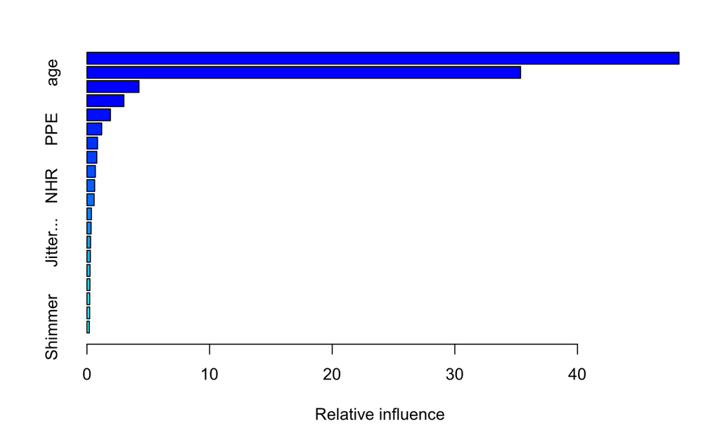

```r
# Model
boost.fit = gbm(total_UPDRS~.-motor_UPDRS, data=P.train, distribution="gaussian",
                 n.trees=5000)

summary(boost.fit)
```

```r
# Performance
boost.pred = predict(boost.fit, newdata=P.test, n.trees=5000)

  # MSE
  mean((boost.pred - test.pk)^2)
```

```
[1] 9.207355
```

```r
  # Find SST and SSE
  b.sst = sum((test.pk - mean(test.pk))^2)
  b.sse = sum((boost.pred - test.pk)^2)

  # find R-Squared
  b.rsq = 1 - (b.sse/b.sst)
  b.rsq
```

```
[1] 0.9199196
```

## 2. Classification problem: build classification models to predict the class variable and measure their performance utilizing the test set

### a. Build a classification model using decision trees

**How does the model perform?** A Decision Tree model was built for the Breast Cancer dataset (classification). The performance was tested using a confusion matrix, which indicated: Accuracy (0.9562), Sensitivity (0.9885) and Specificity (0.9000). Looking at the confusion matrix we are able to see quite good results, the main diagonal indicates a high prediction accuracy with 131 correct predictions out of 137.

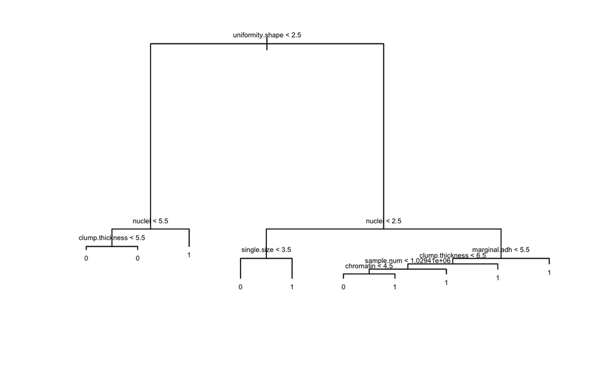

```r
# Model
tree.fit = tree(tumor~., data=BC.train)
plot(tree.fit)
text(tree.fit, pretty=0, cex=0.5)
```

```r
# Prediction
tree.pred = predict(tree.fit, newdata=BC.test, type="class")

# Confusion Matrix
confusionMatrix(data=tree.pred, reference = BC.test$tumor)
```

```
Confusion Matrix and Statistics

          Reference
Prediction  0  1
         0 86  5
         1  1 45

               Accuracy : 0.9562
                 95% CI : (0.9071, 0.9838)
    No Information Rate : 0.635
    P-Value [Acc > NIR] : <2e-16

                  Kappa : 0.9039

 Mcnemar's Test P-Value : 0.2207

            Sensitivity : 0.9885
            Specificity : 0.9000
         Pos Pred Value : 0.9451
         Neg Pred Value : 0.9783
             Prevalence : 0.6350
         Detection Rate : 0.6277
   Detection Prevalence : 0.6642
      Balanced Accuracy : 0.9443

       'Positive' Class : 0
```